# TN, Tax Returns, Education, and How They’re Related

Savage Squadron*, *February 1, 2018

> ```
> Q1: What is the income distribution amongst TN counties?
> ```

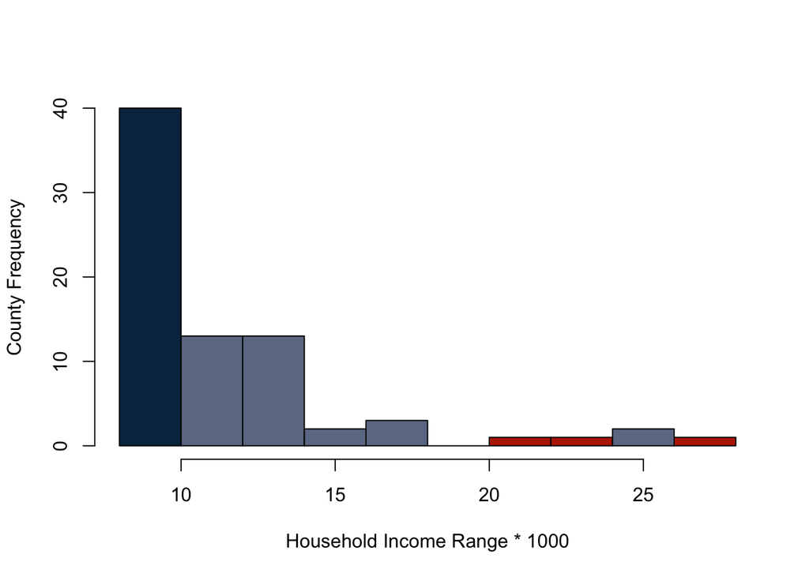

> ```
> Q2: Is there any change in income over the years?
> ```

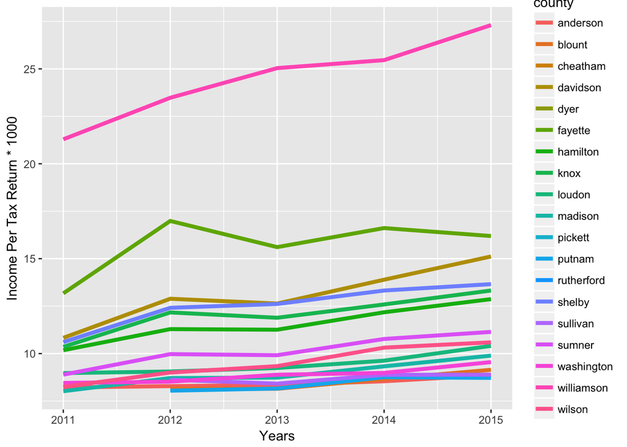

** The majority of counties maintain their rank amongst other counties.

> ```
> Q3: Which counties have highest number of tax filers per year?
> ```

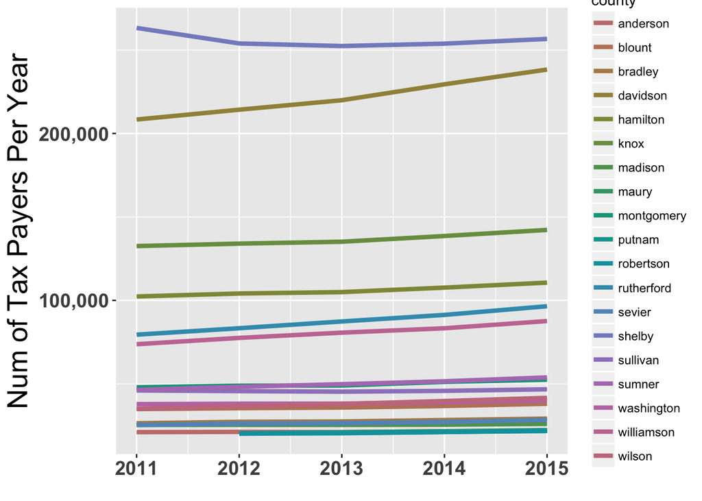

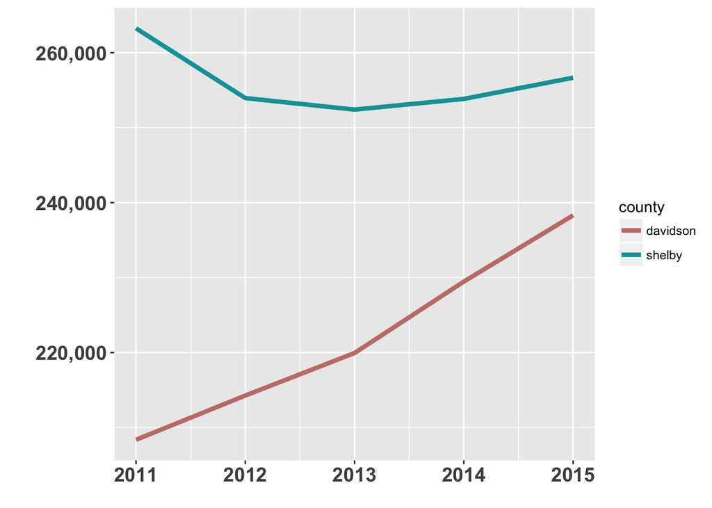

** **Davidson County** is having a consistent increase in the number of tax filers, while **Shelby County** is decreasing.

> ```
> Q4: For 2014, what is the overall situation within our education dataset regarding student graduation, dropout, and suspension?
> ```

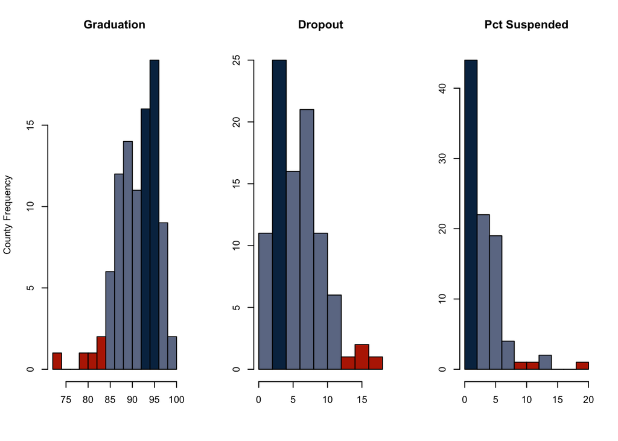

- Graduation rate is highest in Meigs, lowest in *Shelby*.
- Dropout rate is highest in *Shelby* county, while kids are studious in Pickett and Meigs counties.
- Teachers seem to be *very* strict in *Shelby* county, since it holds the highest student suspension rate.

> ```
> Q5: For 2014, what is the overall situation within our education dataset regarding student performance?
> ```

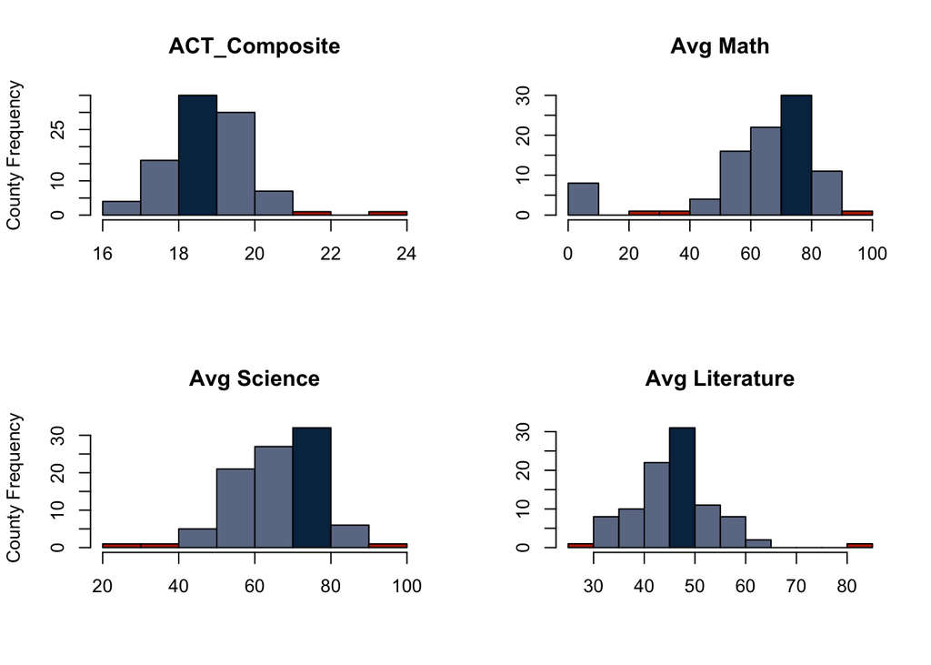

- *Williamson* county is showing highest ACT scores, average mathematics, literature, and second highest in science scores.
- The lowest ACT scores are from Lake and Fayette counties
- The lowest mathematics scores are from Cheatham and Putnam counties.
- *Fentress* takes the lead for the highest science scores at 100%, with Lake being lowest, and *Shelby* 3rd lowest.
- The lowest literature scores are from Hancock county.

> ```
> Q6: For 2014, what is the average ACT Scores per region within TN?
> ```

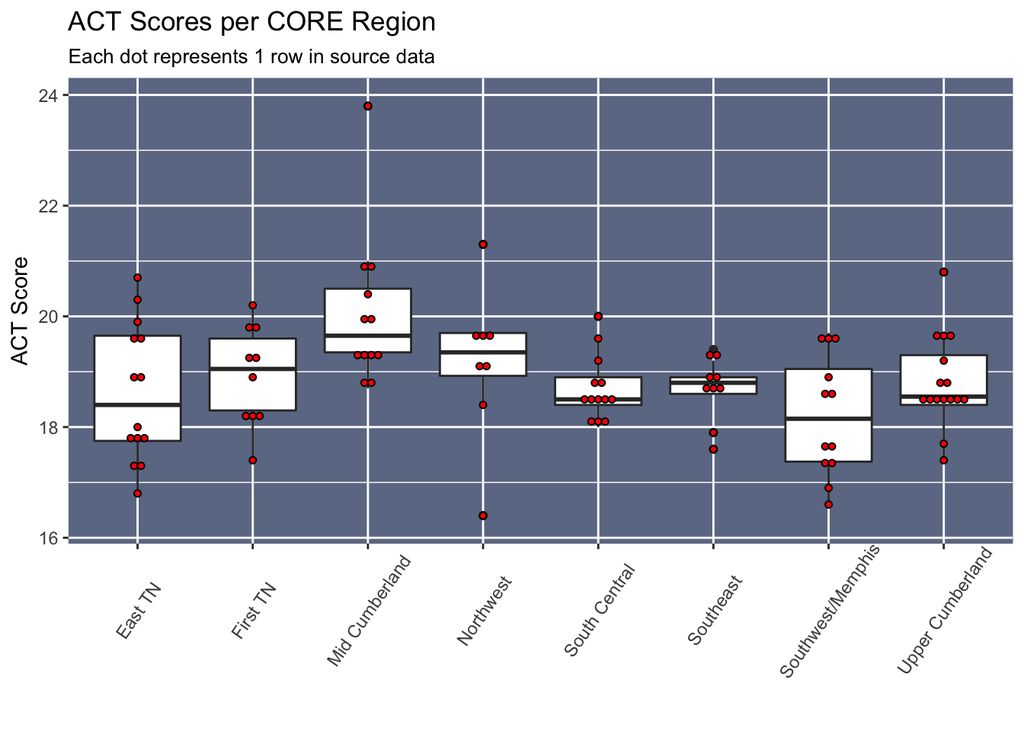

Mid Cumberland show the highest average overall, which also includes Williamson county.

> ```
> Q7: How do dropout, graduation, and ACT scores compare to income scales?
> ```

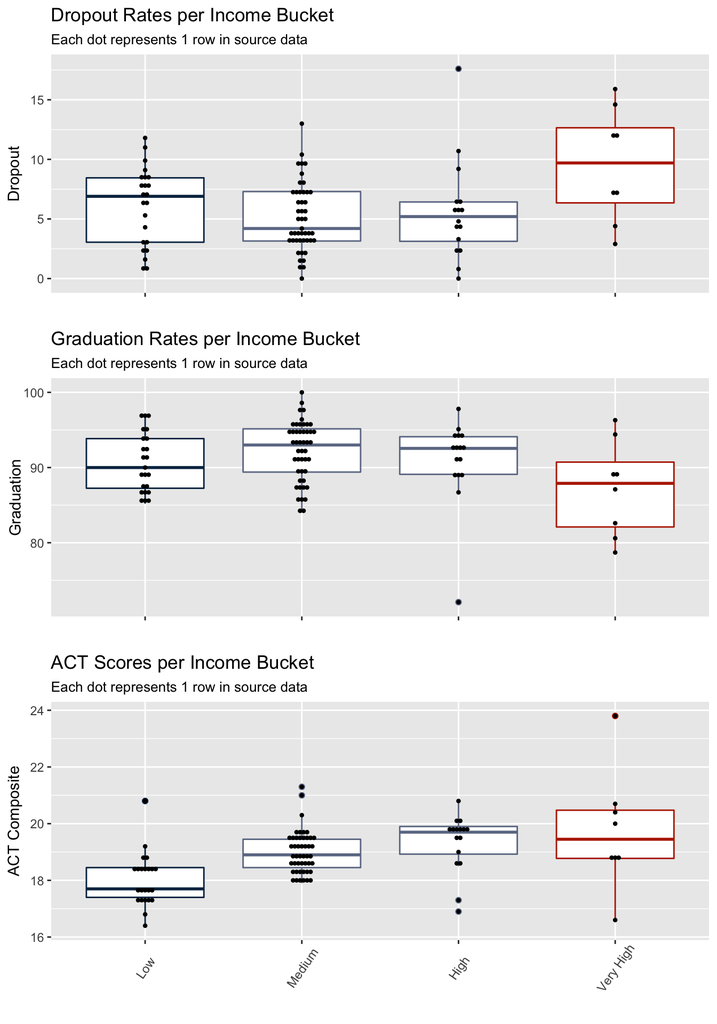

> ```
> Act Scores for the Black and Hispanic populations within TN counties, with size based on Income.
> ```

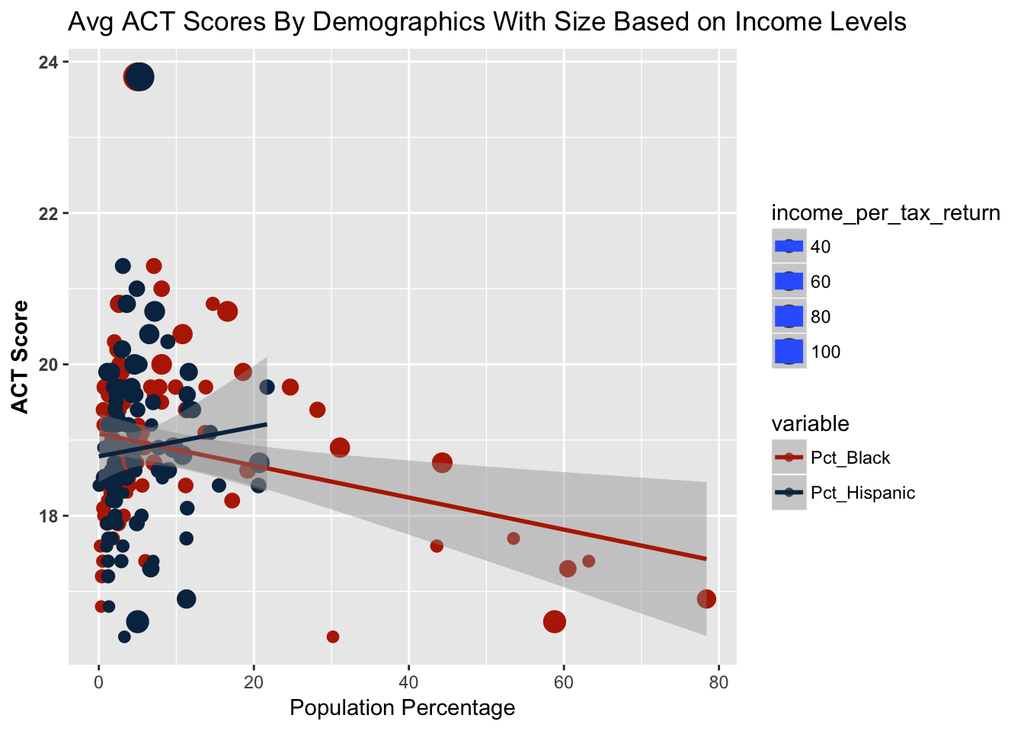

> ```
> Performance Analytics Summary
> ```

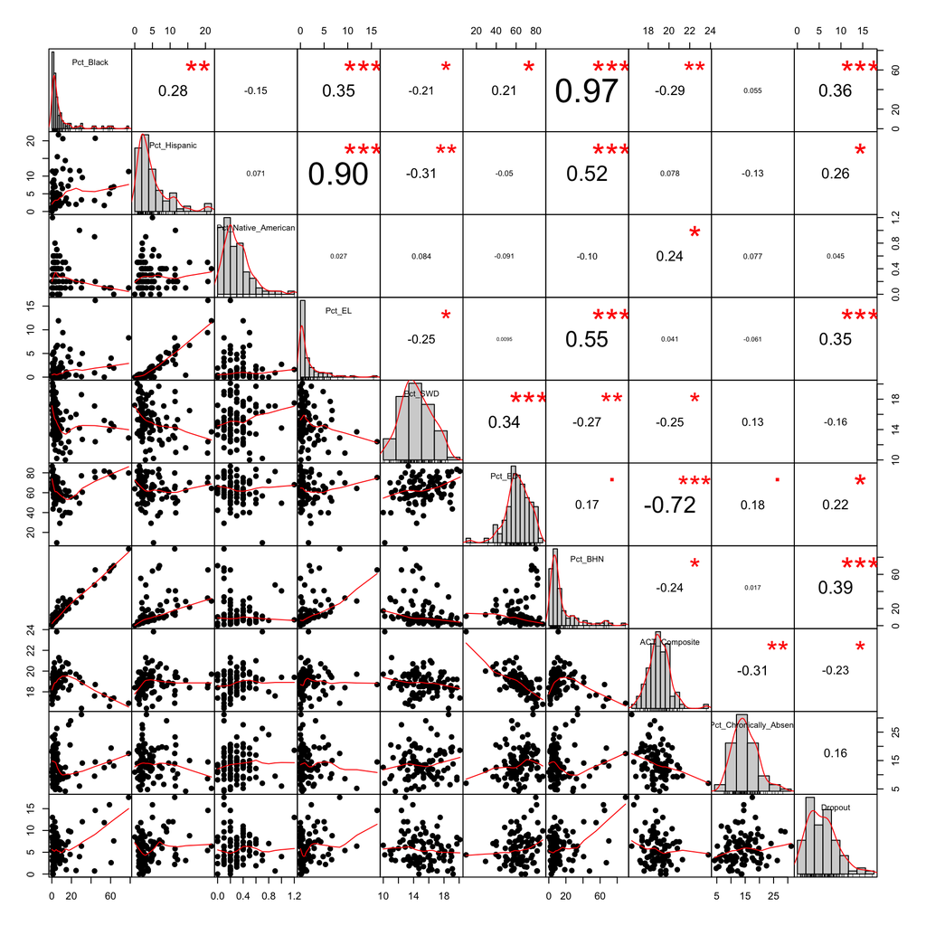